# Multiple Linear Regression I: Confounding

Research Statistics with R — Health Sciences

## Learning objectives

By the end of this lesson you will be able to:

1. Recognise when a bivariate (single-predictor) regression slope is misleading.
2. Define a **confounder** using two simple conditions.
3. Add a categorical or continuous covariate to a regression model in R and interpret the *adjusted* slope.
4. Visualise the difference between an unadjusted and an adjusted relationship using `ggplot2`.

> **Why this matters.** Almost every published health-research finding is reported as an *adjusted* effect. The skill we build today is what separates a usable analysis from one that gets you (or your reader) into trouble.

## Setup

```r
library(tidyverse)   # dplyr, ggplot2, readr
library(broom)       # tidy() for clean regression output
library(knitr)       # kable() for nice tables
theme_set(theme_minimal(base_size = 12))
```

We’ll use a small public-health dataset of the world’s 193 UN member states in 2024 (originally from the `moderndive::un_member_states_2024` package). Each **row is a country**, and each **column is a country-level statistic**.

```r
un <- read_csv("datasets_staging/cleaned/22_un_member_states_2024.csv")
glimpse(un)
```

```
## Rows: 193
## Columns: 13
## $ country               <chr> "Afghanistan", "Albania", "Algeria", "Andorra", …
## $ iso_code              <chr> "AFG", "ALB", "DZA", "AND", "AGO", "ATG", "ARG",…
## $ continent             <chr> "Asia", "Europe", "Africa", "Europe", "Africa", …
## $ region                <chr> "Southern and Central Asia", "Southern Europe", …
## $ income_group          <chr> "Low income", "Upper middle income", "Lower midd…
## $ population            <dbl> 40121552, 3107100, 47022473, 85370, 37202061, 10…
## $ area_km2              <dbl> 652864, 28748, 2381741, 468, 1246700, 442, 27964…
## $ gdp_per_capita_usd    <dbl> 355.7778, 6810.1140, 4342.6380, 41992.7728, 3000…
## $ obesity_rate_2016_pct <dbl> 5.5, 21.7, 27.4, 25.6, 8.2, 18.9, 28.3, 20.2, 29…
## $ obesity_rate_2024_pct <dbl> 10.3, 21.3, 21.8, 13.6, 6.8, 43.1, 32.4, 19.5, 3…
## $ life_expectancy_yrs   <dbl> 53.65, 79.47, 78.03, 83.42, 62.11, 77.80, 78.31,…
## $ fertility_rate        <dbl> 4.3, 1.4, 2.7, NA, 5.0, 1.6, 1.9, 1.6, 1.6, 1.5,…
## $ hdi                   <dbl> 0.462, 0.789, 0.745, 0.884, 0.591, 0.826, 0.849,…
```

The four variables we’ll use today:

| Variable | What it is |
| --- | --- |
| `life_expectancy_yrs` | Average life expectancy at birth, in years (our **outcome**) |
| `obesity_rate_2024_pct` | % of adults classified as obese (our **predictor**) |
| `income_group` | World Bank wealth band: Low / Lower-middle / Upper-middle / High |
| `gdp_per_capita_usd` | GDP per capita, US dollars |

> **Heads-up about the unit of analysis.** Each row in this dataset is a *country*, not a person. Conclusions we draw will be statements about countries (*“a country with X% more obesity tends to …”*), not about individuals. We’ll come back to this distinction.

## Part 1 — A simple research question

A health-policy think-tank asks:

> *“Is a country’s adult obesity rate associated with its life expectancy?”*

You’d probably guess: more obesity, lower life expectancy. Let’s let the data answer.

### Look at each variable on its own

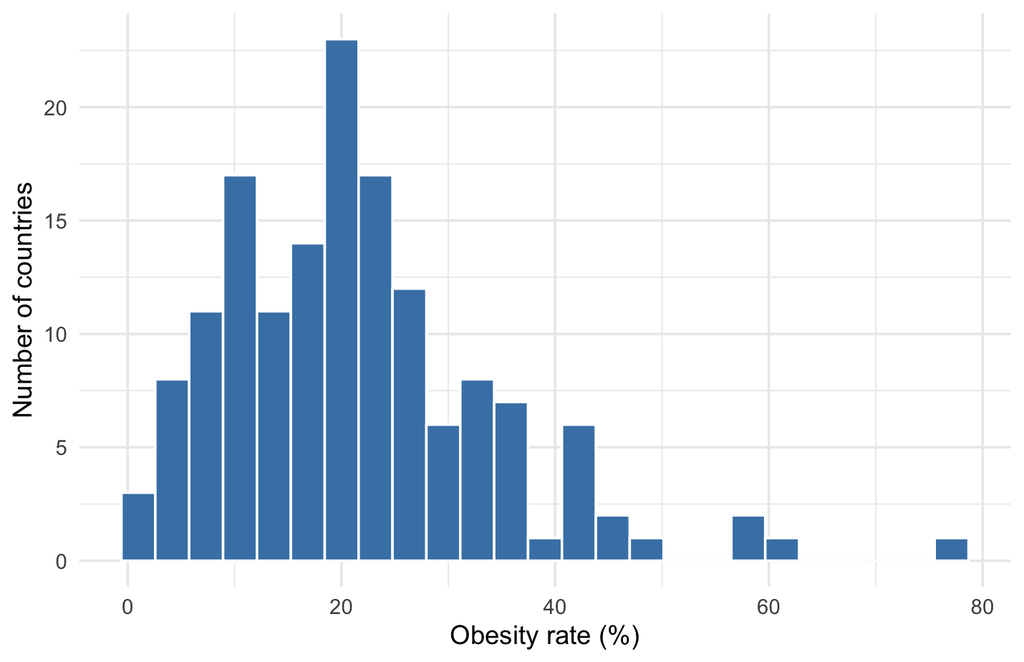

```r
ggplot(un, aes(obesity_rate_2024_pct)) +
  geom_histogram(bins = 25, fill = "steelblue", colour = "white") +
  labs(x = "Obesity rate (%)", y = "Number of countries")
```

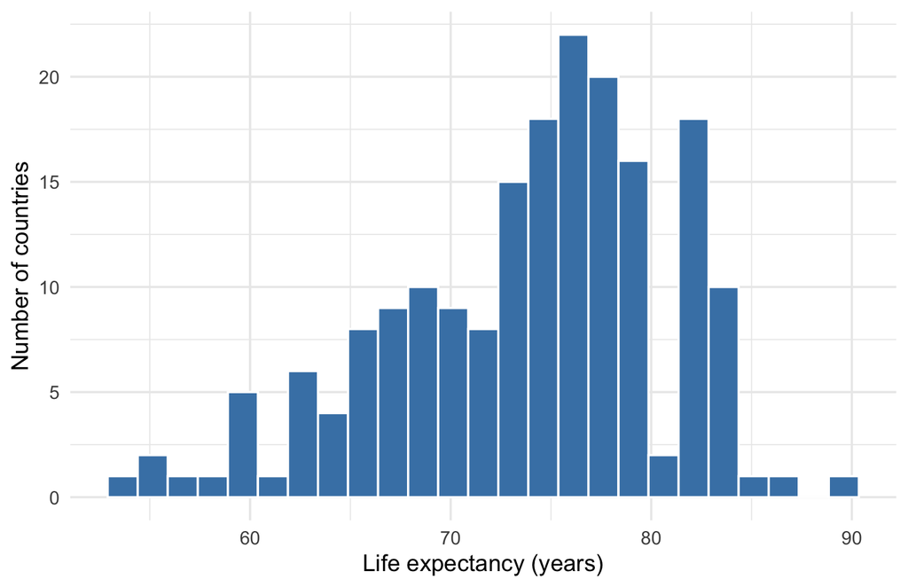

```r
ggplot(un, aes(life_expectancy_yrs)) +
  geom_histogram(bins = 25, fill = "steelblue", colour = "white") +
  labs(x = "Life expectancy (years)", y = "Number of countries")
```

### Bivariate scatter

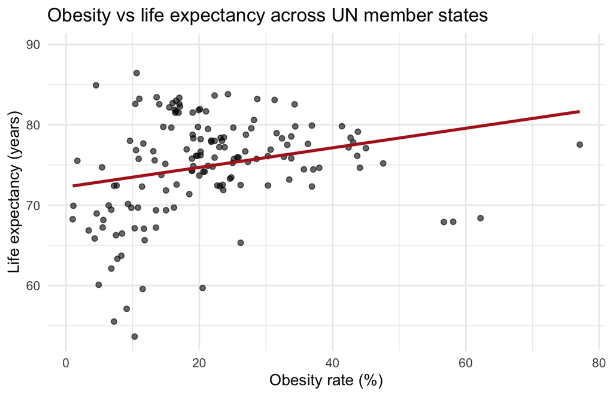

```r
ggplot(un, aes(obesity_rate_2024_pct, life_expectancy_yrs)) +
  geom_point(alpha = 0.6) +
  geom_smooth(method = "lm", se = FALSE, colour = "firebrick") +
  labs(
    x = "Obesity rate (%)",
    y = "Life expectancy (years)",
    title = "Obesity vs life expectancy across UN member states"
  )
```

### Fit the simple regression

```r
mod1 <- lm(life_expectancy_yrs ~ obesity_rate_2024_pct, data = un)
tidy(mod1) |> kable(digits = 3)
```

| term | estimate | std.error | statistic | p.value |
| --- | --- | --- | --- | --- |
| (Intercept) | 72.262 | 0.968 | 74.614 | 0.000 |
| obesity_rate_2024_pct | 0.122 | 0.039 | 3.128 | 0.002 |

```r
glance(mod1) |> select(r.squared, p.value, nobs) |> kable(digits = 3)
```

| r.squared | p.value | nobs |
| --- | --- | --- |
| 0.062 | 0.002 | 150 |

> Does that mean obesity is good for you?

> Discuss with the person next to you for two minutes before reading on.

## Part 2 — Looking for the missing variable

The slope is real in the data, but the **interpretation** (“more obesity → longer life”) is obviously wrong. So a third factor must be making both obesity *and* life expectancy go up together.

### Brainstorm

What kinds of countries have high obesity rates? What kinds of countries have long life expectancy? Where do those lists overlap?

Almost everyone arrives at the same answer: **wealthy countries**.

- Wealthy countries have abundant food, cars, sedentary jobs → high obesity.
- Wealthy countries also have hospitals, sanitation, clean water → long life expectancy.

If wealth drives both, then a simple obesity-vs-life-expectancy comparison is really comparing rich countries to poor countries — and dressing it up as if it were about obesity.

### A way to capture wealth

The dataset has a four-level wealth band: `income_group`.

```r
un |> count(income_group)
```

| income_group | n |
| --- | --- |
| High income | 60 |
| Low income | 26 |
| Lower middle income | 54 |
| Upper middle income | 52 |
| NA | 1 |

### Step A — Does wealth predict the outcome?

If wealth doesn’t actually predict life expectancy, it can’t be a confounder. Let’s check.

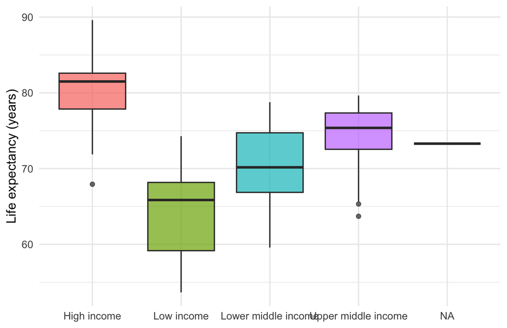

```r
ggplot(un, aes(income_group, life_expectancy_yrs, fill = income_group)) +
  geom_boxplot(alpha = 0.7, show.legend = FALSE) +
  labs(x = NULL, y = "Life expectancy (years)")
```

```r
lm(life_expectancy_yrs ~ income_group, data = un) |>
  tidy() |> kable(digits = 2)
```

| term | estimate | std.error | statistic | p.value |
| --- | --- | --- | --- | --- |
| (Intercept) | 80.28 | 0.57 | 140.58 | 0 |
| income_groupLow income | -15.81 | 1.05 | -15.01 | 0 |
| income_groupLower middle income | -10.04 | 0.84 | -11.98 | 0 |
| income_groupUpper middle income | -5.79 | 0.84 | -6.87 | 0 |

A high-income country lives ~16 years longer than a low-income country. **Big and obvious.**

### Step B — Does wealth track the predictor?

If wealth and obesity are not related, then wealth can’t be inflating the obesity slope either.

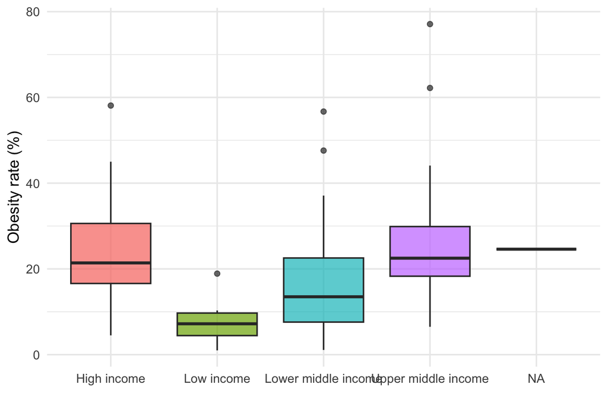

```r
ggplot(un, aes(income_group, obesity_rate_2024_pct, fill = income_group)) +
  geom_boxplot(alpha = 0.7, show.legend = FALSE) +
  labs(x = NULL, y = "Obesity rate (%)")
```

Rich countries have systematically higher obesity rates than poor countries.

> **Definition.** A variable is a **confounder** when it satisfies *both* conditions:
> 1. It is associated with the **outcome**.
> 2. It is associated with the **predictor**.

> We’ve just shown both, by eye, in two boxplots. Income group is a confounder of the obesity → life-expectancy relationship.

## Part 3 — Adjusting for income group

We add `income_group` to the regression and see what happens to the obesity slope.

```r
mod2 <- lm(life_expectancy_yrs ~ obesity_rate_2024_pct + income_group, data = un)
tidy(mod2) |> kable(digits = 3)
```

| term | estimate | std.error | statistic | p.value |
| --- | --- | --- | --- | --- |
| (Intercept) | 79.986 | 0.939 | 85.172 | 0.000 |
| obesity_rate_2024_pct | -0.004 | 0.030 | -0.148 | 0.883 |
| income_groupLow income | -15.397 | 1.500 | -10.263 | 0.000 |
| income_groupLower middle income | -8.761 | 0.923 | -9.487 | 0.000 |
| income_groupUpper middle income | -5.212 | 0.861 | -6.055 | 0.000 |

### Side-by-side comparison

```r
bind_rows(
  tidy(mod1) |> filter(term == "obesity_rate_2024_pct") |> mutate(model = "Bivariate"),
  tidy(mod2) |> filter(term == "obesity_rate_2024_pct") |> mutate(model = "Adjusted for income_group")
) |>
  select(model, estimate, std.error, p.value) |>
  kable(digits = 3, caption = "Obesity slope before vs after adjustment")
```

Obesity slope before vs after adjustment

| model | estimate | std.error | p.value |
| --- | --- | --- | --- |
| Bivariate | 0.122 | 0.039 | 0.002 |
| Adjusted for income_group | -0.004 | 0.030 | 0.883 |

> **Plain-English reading.** *Among countries in the same income group, obesity rate is not meaningfully associated with life expectancy.* The original positive slope was income hiding inside the obesity coefficient.

### Visualise what “adjusting” does

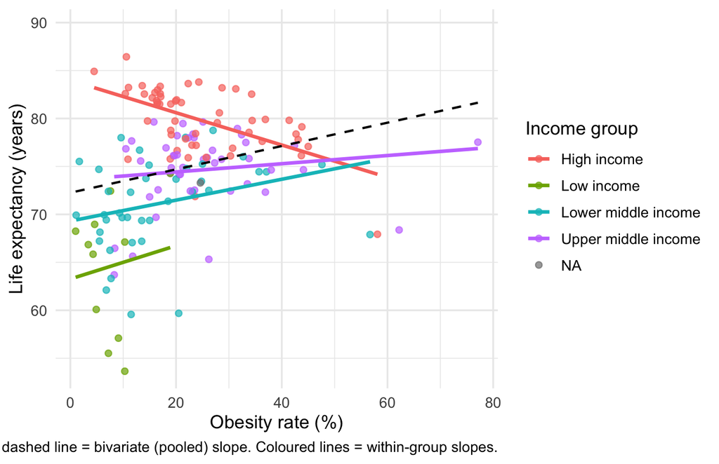

```r
ggplot(un, aes(obesity_rate_2024_pct, life_expectancy_yrs, colour = income_group)) +
  geom_point(alpha = 0.7) +
  geom_smooth(method = "lm", se = FALSE) +
  geom_smooth(method = "lm", se = FALSE,
              aes(group = 1), colour = "black", linewidth = 0.7, linetype = "dashed") +
  labs(
    x = "Obesity rate (%)",
    y = "Life expectancy (years)",
    colour = "Income group",
    caption = "Black dashed line = bivariate (pooled) slope. Coloured lines = within-group slopes."
  )
```

## Part 4 — A fully continuous version of the same lesson

In real research you’ll often face a continuous confounder rather than a tidy categorical one. The same logic applies. Let’s redo Part 3 with **GDP per capita** standing in for “wealth”.

### Why we use `log(gdp_per_capita_usd)`

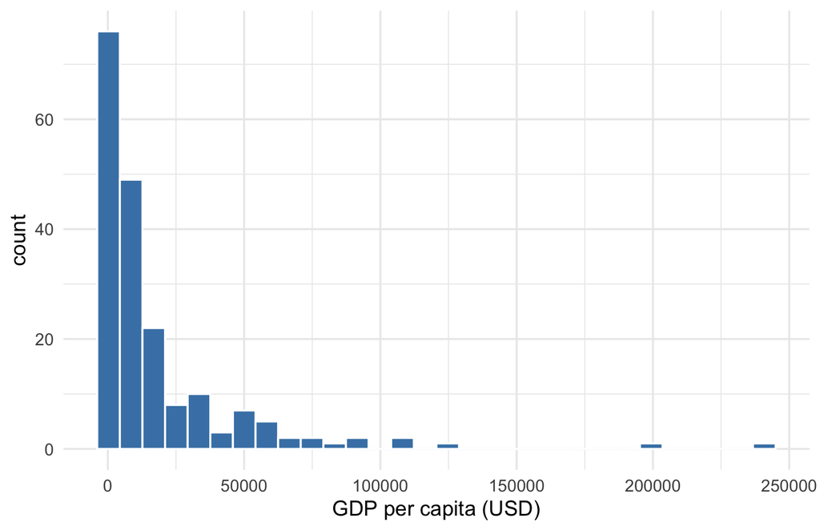

```r
ggplot(un, aes(gdp_per_capita_usd)) +
  geom_histogram(bins = 30, fill = "steelblue", colour = "white") +
  labs(x = "GDP per capita (USD)")
```

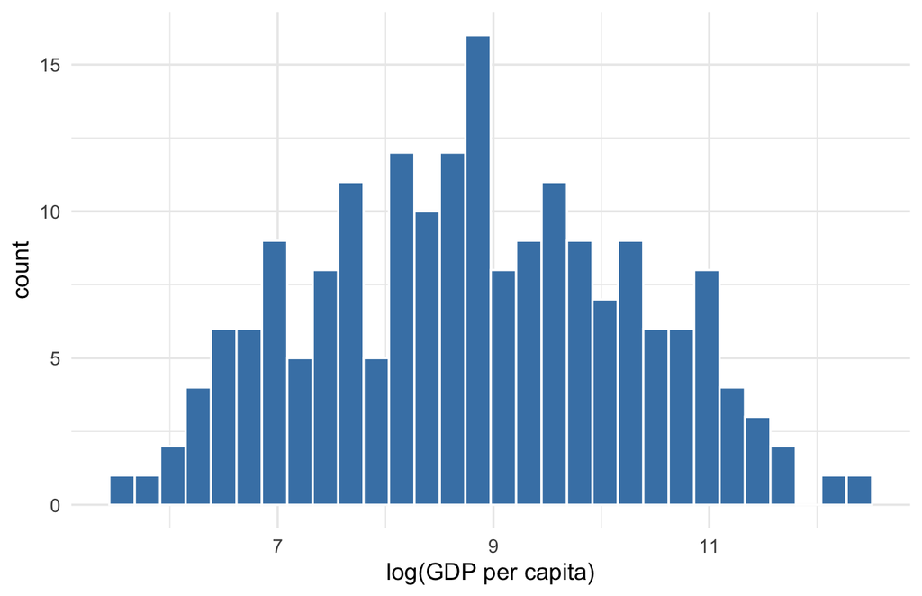

```r
ggplot(un, aes(log(gdp_per_capita_usd))) +
  geom_histogram(bins = 30, fill = "steelblue", colour = "white") +
  labs(x = "log(GDP per capita)")
```

GDP per capita is extremely right-skewed: a handful of very wealthy countries dwarf everyone else. Going from $1,000 to $5,000 buys a lot of life expectancy; going from $50,000 to $54,000 barely moves it. A log transform respects that, and gives the regression a *linear* version of “wealth” to work with.

### The same two-model comparison

```r
mod3 <- lm(life_expectancy_yrs ~ obesity_rate_2024_pct + log(gdp_per_capita_usd),
           data = un)

bind_rows(
  tidy(mod1) |> filter(term == "obesity_rate_2024_pct") |> mutate(model = "Bivariate"),
  tidy(mod3) |> filter(term == "obesity_rate_2024_pct") |> mutate(model = "Adjusted for log(GDP)")
) |>
  select(model, estimate, std.error, p.value) |>
  kable(digits = 3, caption = "Obesity slope: bivariate vs adjusted for log(GDP)")
```

Obesity slope: bivariate vs adjusted for log(GDP)

| model | estimate | std.error | p.value |
| --- | --- | --- | --- |
| Bivariate | 0.122 | 0.039 | 0.002 |
| Adjusted for log(GDP) | 0.010 | 0.025 | 0.707 |

> **Why didn’t we just adjust for HDI?** HDI looks tempting — it’s a UN composite of “human development”. But it is *built from life expectancy itself*, so adjusting for it would be partly subtracting the outcome from itself. The general lesson: a “good control” must be a *cause* of the outcome, not a *consequence* or a *redefinition* of it.

## Part 5 — Putting it together

We’ve now seen the same pattern twice in the same dataset, once with a categorical confounder and once with a continuous one. The shape of the lesson is identical:

1. A bivariate slope answers **“what does the data look like?”**, not **“what causes what?”**.
2. A variable is a **confounder** when it is associated with both the outcome and the predictor.
3. Including a confounder in your regression — `lm(y ~ x + z)` — gives you the **adjusted** slope of `x`: the relationship that survives after `z` has been accounted for.
4. The adjusted slope can be **smaller**, **zero**, or even **opposite-signed** compared to the unadjusted one. Reporting the unadjusted slope as your headline finding is the most common mistake in applied research.

## Try it yourself

The dataset has another well-known confounder of life expectancy: `fertility_rate`. Repeat the analysis with `fertility_rate` in place of `income_group`:

```r
mod_exercise <- lm(life_expectancy_yrs ~ obesity_rate_2024_pct + fertility_rate,
                   data = un)
tidy(mod_exercise)
```

Answer these:

1. What happens to the obesity slope after adjusting for fertility rate?
2. Is fertility rate associated with the **outcome** (life expectancy)?
3. Is fertility rate associated with the **predictor** (obesity rate)?
4. Does fertility rate satisfy *both* conditions for being a confounder?
5. Is fertility rate a confounder *because of itself*, or because it is a proxy for something else (think back to Part 2)?

## A preview for next week

Look back at the stratified plot in Part 3.

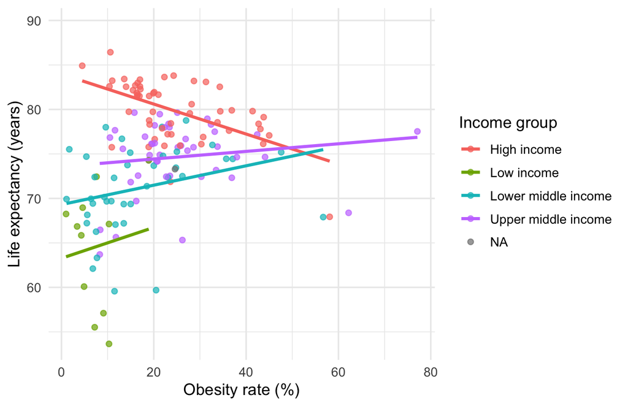

That’s not confounding — that’s a brand-new phenomenon called an **interaction** or **effect modification**, and it’s what we’ll model next week. Same dataset, different question.